# Write-up: Yelp Restaurant Rating Model

Meredith Manley and Caleigh Plaut

12/18/17

# Abstract

Our project utilizes the Yelp Fusion API to identify variables that have a meaningful relationship with Yelp rating and incorporate them into a predictive model in the hope of forecasting Yelp rating for a specific restaurant. We narrowed the observations to restaurants in the top ten cities in the United States and randomly selected 50 restaurants from each of these cities, leaving us with 500 observations to work with in total – 450 observations in our training set and 50 observations in our test set. We focused on the relationship between the following variables during our explanatory analysis: distance from the city center and `rating`, `price` and `rating`, and `review_count` and `rating`. We found that the variable `review_count` had a significant correlation with `rating` and thus would expect that it should be somewhat predictive when included in a model. We decided to treat `rating` as a numerical outcome as well as a categorical outcome for different types of models given that `rating` is a numeric variable with 5 levels. We implemented a multivariate linear regression and a univariate spline model on `rating` as a numerical value and then a classification and regression tree (CART) model on `rating` as a categorical variable. Although it is difficult to compare the accuracy of a model predicting a numerical outcome versus a model predicting categorical outcome, we determined that both methods perform relatively well.

# Introduction

As frequent Yelp users, we wanted to determine what factors influence the Yelp ratings of restaurants. Typically, the first thing that we look at when going on Yelp is the overall star rating of a restaurant; a rating of one star means that the restaurant should probably be avoided, while a rating of five stars means that the restaurant has clearly achieved success. However, we have both eaten at restaurants whose rating does not do it justice or gives it too much credit. Considering that Yelp reviews and ratings are created by a mélange of serious food critics, everyday foodies and individuals, who held a grudge against their waiter, we wanted to look behind the façade of the star rating and see what confounding factors may influence restaurant ratings other than customer satisfaction and service quality.

#### Figure 1: Association Between `distance` and `rating`

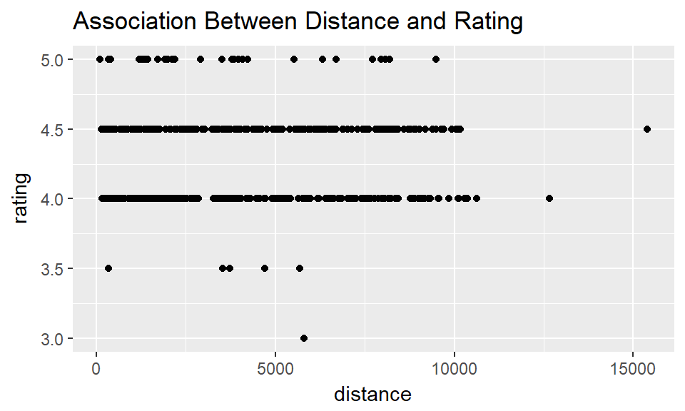

#### Figure 2: Association Between `review_count` and `rating` Relative to `price`

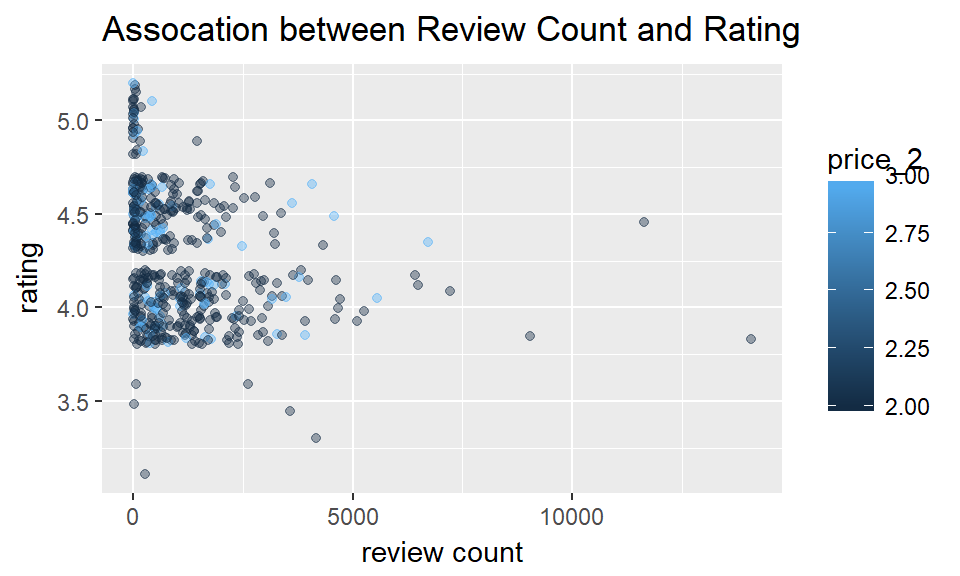

```
## [1] -0.2738796
```

Our exploratory analysis also looks at the distribution of the Yelp rating below in *Figure 3*. Given the limited range of ratings, the distribution looks fairly normal. Had the data been significantly skewed to the left or right, we may have needed to include some kind of transformation to the Yelp rating variable before developing our predictive models.

#### Figure 3: Distribution of Outcome Variable - `rating`

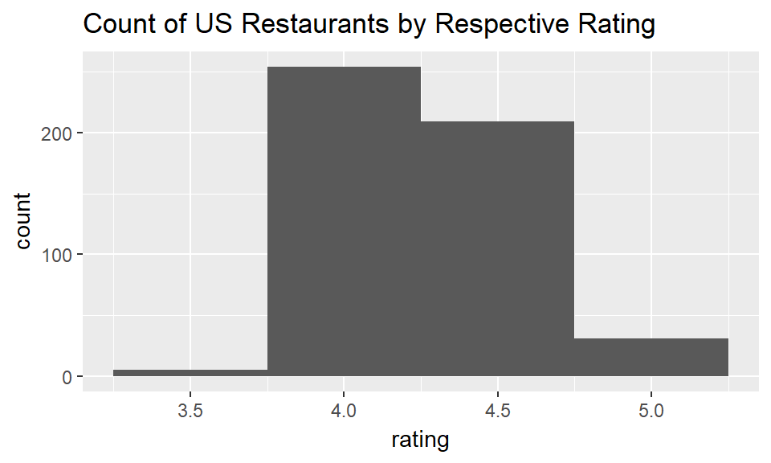

When developing a predictive model for Yelp ratings we wanted to experiment with multiple methods and compare their results to ultimately determine which model is most accurate for this specific outcome variable. We initially treated `rating` as a numerical value and trained a multivariate linear regression model dependent on all variables in our dataset: `review_count`, `distance`, `is_open`, `price_2`, `latitude`, and `longitude`. We calculated the Means Squared Error (MSE) on the train set and the test set. The MSE from the train set will act as more of a check for overfitting and the MSE from the test set will measure the models accuracy. In both of our models which predict `rating` as a numeric outcome there was not much evidence of overfitting as the MSE from our test set lower than that of our training set.

Next, we performed a stepwise regression to trim our model of any variables that may not contribute significantly to our model. Based on these results and evidence from our exploratory analysis, we ran a univariate spline model which was dependent on only one predictor from our dataset, `review_count`. We calculated the MSE for the train and test, again, to check for overfitting and strength of model. For the final step of our project, we converted `rating` into a categorical variable and trained a CART model. While we cannot calculate a MSE for classification algorithm we determined our accuracy percentage for this model.

# Data

The data is from the Yelp Fusion API. This API provides access to information for reviewed businesses on Yelp. We extracted observations from restaurants in the top ten largest cities in the United States using a for-loop and code found online that was provided by Prof. Alex Baldenko. These cities are in different regions of the United States as seen in the map below in Figure 4, so we are somewhat able to account for variations in Yelp ratings due to regional difference. We pulled 50 observations from each city as the API limits how many observations you can pull at one time. Our sample size was composed of 500 observations—450 of these observations would be included in the train set and 50 would be included in the test set.

#### Figure 4: Map of 10 Largest Cities in the US

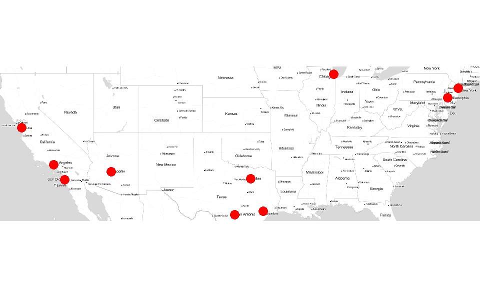

The response variable in our models is called `rating` in the Yelp API and indicates the rating of a given restaurant according to Yelp. It is a discrete variable and has the type decimal—its possible values are 1, 1.5, 2, 2.5, 3, 3.5, 4, 4.5 and 5. Thus, there is a tight range of values that the models can predict for rating.

We used the numeric variable `review_count` as a predictor in all our models. `review_count` refers to the number of reviews a given establishment has and is in an integer. Geographic variables, such as `distance` (refers to the distance in meters from the search location), `latitude` (refers to the latitude of a given business) and `longitude` (refers to the longitude of a given business), are numeric variables and are included in our first model, multivariate linear regression model, and last model, classification algorithm.

We transformed the categorical variable `price`, which refers to how expensive, or inexpensive, a given establishment is. Because the price level is represented as dollar signs on Yelp—one dollar sign represents a relatively inexpensive menu and four dollar signs represent a relatively expensive menu – this would not have contributed to our model. We converted `price` into an ordinal variable by substituting a “1” where there was one dollar sign, a “2” where there was two dollar signs, so on and so forth to preserve the categorical nature of this variable. We also transformed the variable `is_closed`, a Boolean variable that is true when a restaurant is permanently closed and false otherwise, to a variable that is true when a restaurant is not permanently closed, which we named `is_open`.

#### Sample of Data

```
## # A tibble: 6 x 15
##      X1                      name       phone is_closed rating distance
##   <int>                     <chr>       <dbl>     <lgl>  <dbl>    <dbl>
## 1     1          Burger & Lobster 16468337532     FALSE    4.0 3860.923
## 2     2            Joe's Shanghai 12122338888     FALSE    4.0 1066.509
## 3     3                   Upstate 16467915400     FALSE    4.5 2411.919
## 4     4               "Am\xe9lie" 12125332962     FALSE    4.5 3036.049
## 5     5 Tasty Hand-Pulled Noodles 12127911817     FALSE    4.0 1020.196
## 6     6           Jacob's Pickles 12124705566     FALSE    4.0 9166.965
## # ... with 9 more variables: review_count <int>, price <chr>, city <chr>,
## #   state <chr>, zipcode <int>, latitude <dbl>, longitude <dbl>,
## #   price_2 <int>, is_open <int>
```

# Results

We constructed three models on the scraped data to predict a Yelp rating on a given restaurant: multivariate linear regression model, univariate spline model, classification and regression tree model. In the first two models, `rating` is a numeric variable whereas in the classification algorithm, CART, `rating` is an ordinal categorical variable.

## Numerical Outcome Variable

### Model 1: Multiple Linear Regression

We obtained the following multivariate linear regression model from our training data:
$$\hat{rating} = \hat{\beta_0} + \hat{\beta_1}*reviewcount + \hat{\beta_2}*distance + \hat{\beta_3}*isopen + \hat{\beta_4}*price2 + \hat{\beta_5}*latitude + \hat{\beta_6}*longitude$$

#### Summary of Model 1

```r
summary(model_mlm)
```

```
##
## Call:
## lm(formula = model_formula, data = train)
##
## Residuals:
##      Min       1Q   Median       3Q      Max
## -1.29891 -0.26979 -0.04694  0.20800  0.86617
##
## Coefficients: (1 not defined because of singularities)
##                Estimate Std. Error t value Pr(>|t|)
## (Intercept)   4.206e+00  2.375e-01  17.707  < 2e-16 ***
## review_count -5.875e-05  1.042e-05  -5.639 3.05e-08 ***
## distance      2.855e-06  5.664e-06   0.504    0.615
## is_open              NA         NA      NA       NA
## price_2       5.810e-02  3.938e-02   1.475    0.141
## latitude      7.065e-04  4.117e-03   0.172    0.864
## longitude     4.104e-04  1.079e-03   0.380    0.704
## ---
## Signif. codes:  0 '***' 0.001 '**' 0.01 '*' 0.05 '.' 0.1 ' ' 1
##
## Residual standard error: 0.3105 on 444 degrees of freedom
## Multiple R-squared:  0.07947,    Adjusted R-squared:  0.06911
## F-statistic: 7.666 on 5 and 444 DF,  p-value: 6.302e-07
```

From the result above we see that, for example, the coefficient associated with `review_count` indicates that when all other variables are held constant as we increase `review_count` by 1 `rating` decreases by 5.875e-05 as the coefficient is -5.875e-05. The same can be said for every other variable included in this model. Additionally, when we look at the p-values for each value we see that `review_count` is the only significant variable in this model, thus by the negative coefficient and its significance, this confirms our hypothesis from the exploratory analysis that `review_count` would be an effective predictor of `rating`.

#### Model 2: Spline

From our spline model based on the single predictor, `review_count` to predict `rating`, we arrived at a test set MSE value of 0.06104747. Comparing this test MSE to the test MSE from the multivariate linear regression model we see that this MSE is lower and, therefore, does a better job predicting `rating`.

### Categorical Outcome Variable with > 2 levels

#### Model 3: CART

The last technique we wanted to implement was a classification algorithm. For this model we treated `rating` as an ordinal categorical variable with 5 levels (3.0, 3.5, 4.0, 4.5, and 5.0) as opposed to a numeric variable as was the case for the multivariate linear regression model and the spline model. Since we cannot calculate an MSE value for this model we calculated the percentage of times that this model predicted the rating accurately. 64% of the time our classification algorithm correctly predicted the rating of a particular model.

In conclusion, we see that the univariate spline model dependent on the predictor `review_count` performs better than the multivariate linear regression model that utilizes all the available variables in the dataset when `rating` is treated as a discrete numeric outcome. Their MSE values were 0.06104747 and 0.07471997, respectively. When we choose to develop a classification algorithm for `rating` as an ordinal categorical variable, we predict the correct Yelp rating 64% of the time.

# Diagnostics

### Discrete Numerical Outcome Variable

### Model 1: Multiple Linear Regression

#### Variable selection with Stepwise Regression

The next step that we took in our model development was to perform a stepwise regression on our multivariate linear regression model for it’s ability to select the best performing predictors.

```
## Start:  AIC=-1046.52
## rating ~ review_count + distance + is_open + price_2 + latitude +
##     longitude
##
##
## Step:  AIC=-1046.52
## rating ~ review_count + distance + price_2 + latitude + longitude
##
##                Df Sum of Sq    RSS     AIC
## - latitude      1   0.00284 42.822 -1048.5
## - longitude     1   0.01395 42.833 -1048.4
## - distance      1   0.02449 42.844 -1048.3
## <none>                      42.819 -1046.5
## - price_2       1   0.20990 43.029 -1046.3
## - review_count  1   3.06654 45.886 -1017.4
##
## Step:  AIC=-1048.49
## rating ~ review_count + distance + price_2 + longitude
##
##                Df Sum of Sq    RSS     AIC
## - distance      1    0.0220 42.844 -1050.2
## - longitude     1    0.0242 42.846 -1050.2
## <none>                      42.822 -1048.5
## - price_2       1    0.2108 43.033 -1048.3
## + latitude      1    0.0028 42.819 -1046.5
## - review_count  1    3.1963 46.019 -1018.1
##
## Step:  AIC=-1050.25
## rating ~ review_count + price_2 + longitude
##
##                Df Sum of Sq    RSS     AIC
## - longitude     1    0.0122 42.856 -1052.1
## <none>                      42.844 -1050.2
## - price_2       1    0.2702 43.115 -1049.4
## + distance      1    0.0220 42.822 -1048.5
## + latitude      1    0.0004 42.844 -1048.3
## - review_count  1    3.1814 46.026 -1020.0
##
## Step:  AIC=-1052.13
## rating ~ review_count + price_2
##
##                Df Sum of Sq    RSS     AIC
## <none>                      42.856 -1052.1
## - price_2       1    0.3053 43.162 -1050.9
## + longitude     1    0.0122 42.844 -1050.2
## + distance      1    0.0100 42.846 -1050.2
## + latitude      1    0.0052 42.851 -1050.2
## - review_count  1    3.2446 46.101 -1021.3
```

```
## Stepwise Model Path
## Analysis of Deviance Table
##
## Initial Model:
## rating ~ review_count + distance + is_open + price_2 + latitude +
##     longitude
##
## Final Model:
## rating ~ review_count + price_2
##
##
##          Step Df    Deviance Resid. Df Resid. Dev       AIC
## 1                                  444   42.81940 -1046.515
## 2   - is_open  0 0.000000000       444   42.81940 -1046.515
## 3  - latitude  1 0.002839413       445   42.82224 -1048.486
## 4  - distance  1 0.022046682       446   42.84428 -1050.254
## 5 - longitude  1 0.012204801       447   42.85649 -1052.126
```

We see that the initial model is our original multivariate linear regression model and the final model is trimmed version of our multivariate linear regression model which indicates that out of all of the variables that were included in the initial model, the only variables that contribute most to the prediction of `rating` are `review_count` and `price_2`. Because we have come across sufficient evidence that `review_count` is a strong predictor of `rating` we will drop `price_2` and create a univariate spline model with just `review_count` as our predictor.

#### Model 2: Spline

We then developed a spline model based on the single predictor, `review_count` to predict `rating`. We arrived at this model by performing a cross validation on the model to determine the appropriate value for the degrees of freedom and concluded that when df=10 then this is when the MSE is the lowest for the model. With this trained model we found that overall this model was not overfit to the training set because the MSE from the training set was higher (0.08425069) than the MSE from the test set which was reported to be 0.06104747.

#### Plot of Spline Model

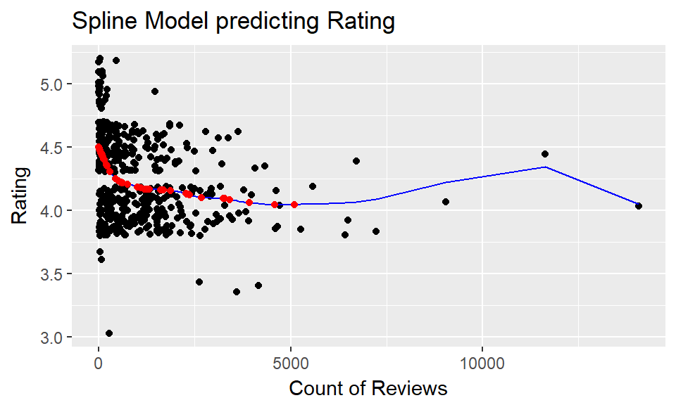

In the plot above we see the spline model and it’s predictions imposed on the actual observations from the training set and how it appears to accurately predict the trend of the data.

### Categorical Outcome Variable with > 2 levels

#### Model 3: CART

For the classification algorithm we treated `rating` as an ordinal categorical variable with 5 levels (3.0, 3.5, 4.0, 4.5, and 5.0) as opposed to a numeric variable as was the case for the multivariate linear regression model and the spline model. Because all of our observations in the test set were at least a 4.0 and we had observations in the training set that were below a 4.0 we experienced issues when running this model. We discovered that there were only 6 observations in the training set that had a rating below 4.0, so we decided to remove these from our training set and proceed to train this model on 444 observations. Since we cannot calculate an MSE value for this model we calculated the percentage of times that this model predicted the rating accurately.

# Conclusion

However, our data set and model did have limitations. The Yelp API was missing many variables that could have had an even better predictive value than review count, such as type of food or number of restaurants in the same area. If we could do this project again, we would merge the Yelp API data with another data set that has additional characteristics about the restaurants. In addition, we would extract more observations from the Yelp API to make the predictive models more accurate in their forecasting. We did not know that we could surpass the limit of results per request, so we limited ourselves to 500 observations. Lastly, when developing our CART model we ran into the issue where there were levels of the rating variable that were observed in the training set, but not in the test set. Although there were only six of these observations that we removed from our dataset this still is something important we wanted to note.

Given the strict timeline of this project, we were not able to explore this topic as deeply as we would have liked. If we had the opportunity to extend our analysis it would be interesting to see if our models could be highly predictive for restaurants in smaller cities in the United States, as well as cities outside the United States. In addition, we would like to explore other models that could better forecast Yelp ratings, such as other classification algorithms to compare how well our CART model performed, and include additional variables that incorporate restaurant characteristics into these models.